# Analyses of 27 years of stand structure development and basal area growth response to a range of initial basal area density levels, 1992-2019

## 1.6 APPENDICES/SUPPLEMENTARY MATERIALS

Appendix 1: Number of growing seasons between each measurement period

| Measurement Year | Growing Seasons |
| --- | --- |
| 1992 | NA |
| 1994 | 3 |
| 1997 | 3 |
| 2009 | 11 |
| 2019 | 11 |

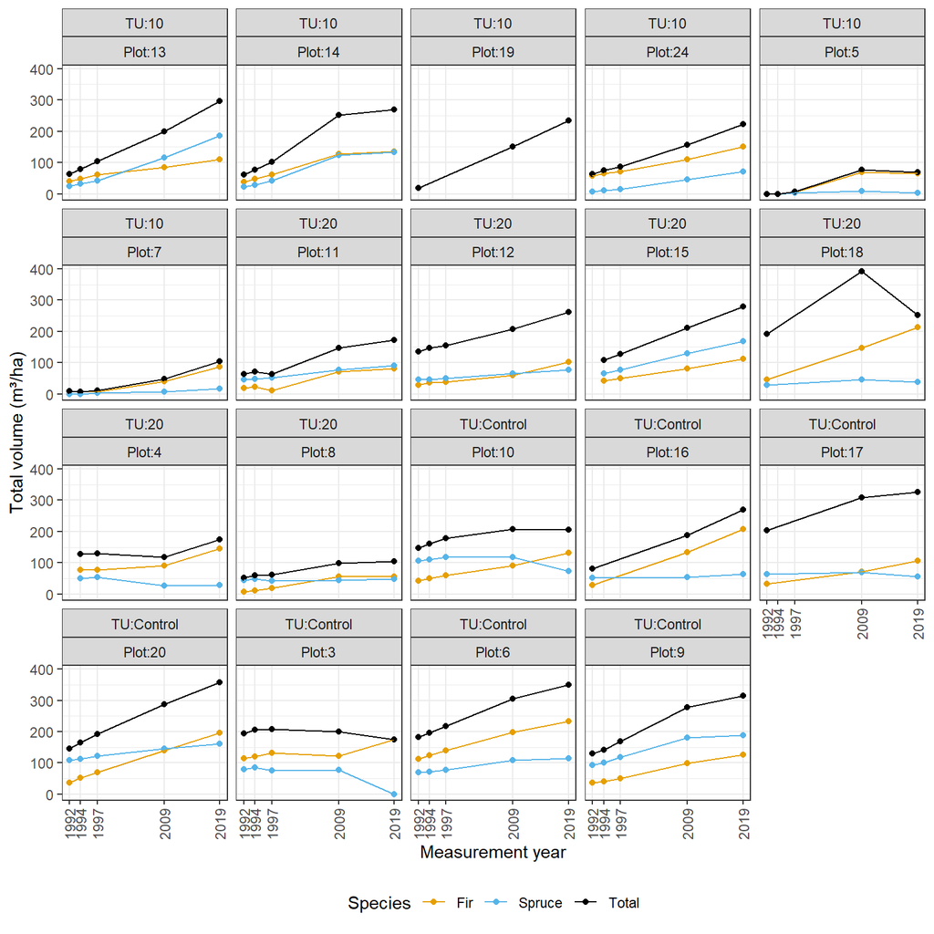

Appendix 2: Plot total volume for five measurement periods

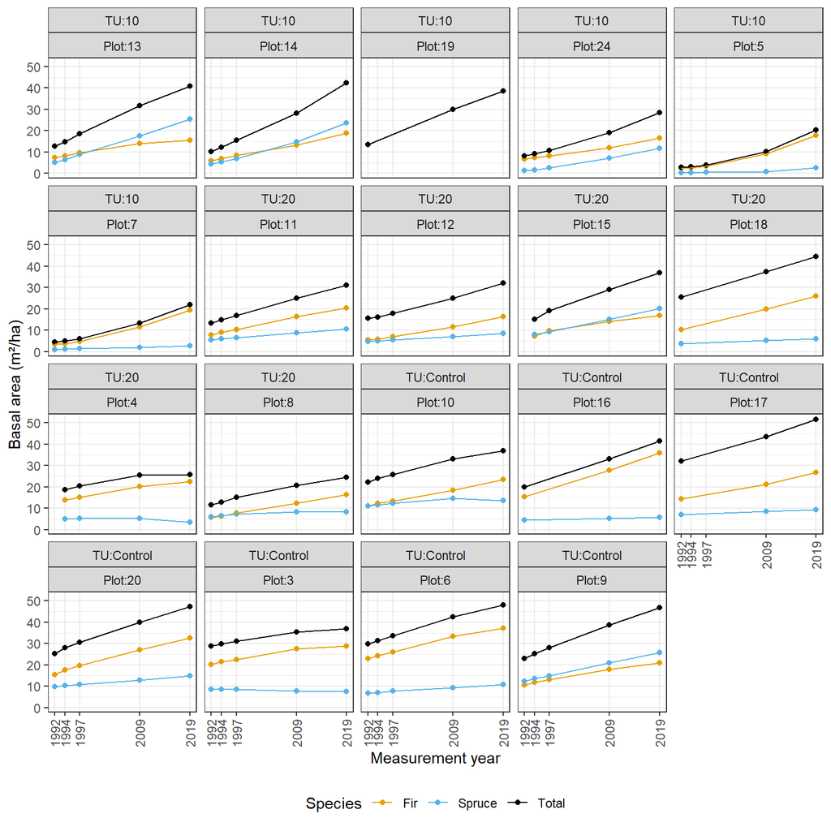

Appendix 3: Plot basal area for five measurement periods

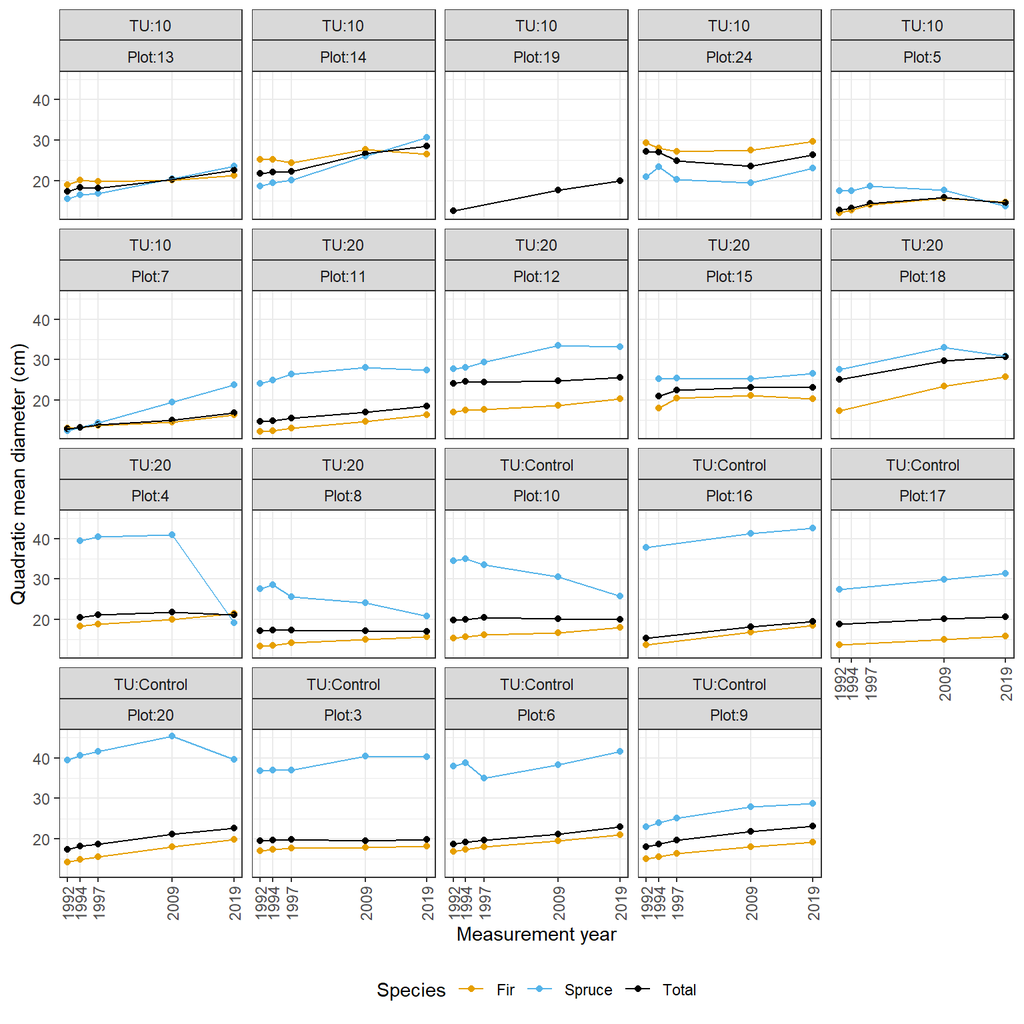

Appendix 4: Plot quadratic mean diameter for five measurement periods

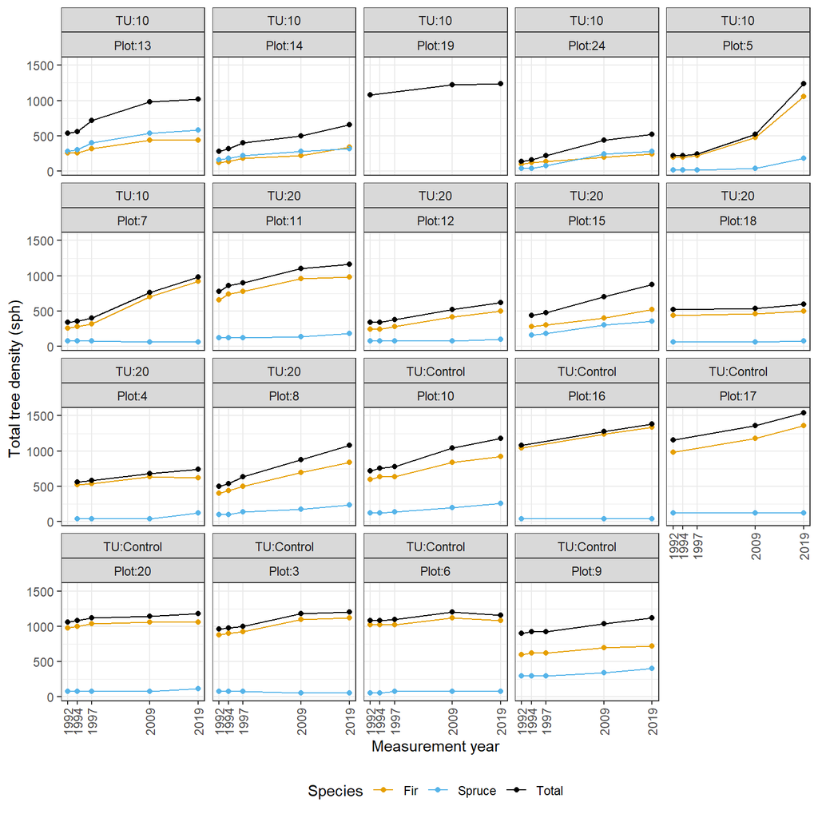

Appendix 5: Plot tree density for five measurement periods

Appendix 6: Contrasts between predicted fir and spruce growth across treatment units and initial diameter classes. Ratio between predicted fir and growth is in ‘ratio’ column.

| contrast | BA.Target | df | t.ratio | p.value | DBH.1992 | ratio | SE |
| --- | --- | --- | --- | --- | --- | --- | --- |
| Bl / Sx | 10 | 369.5674 | -4.62972 | 0.00001 | 10 | 0.41917 | 0.07872 |
|  |  |  |  |  | 20 | 0.53752 | 0.07207 |
|  |  |  |  |  | 30 | 0.62169 | 0.06383 |
|  |  |  |  |  | 40 | 0.68929 | 0.05540 |
|  |  |  |  |  | 50 | 0.74675 | 0.04710 |
|  | 20 | 502.3225 | -0.28094 | 0.77887 | 10 | 0.93273 | 0.23120 |
|  |  |  |  |  | 20 | 0.95150 | 0.16839 |
|  |  |  |  |  | 30 | 0.96265 | 0.13044 |
|  |  |  |  |  | 40 | 0.97064 | 0.10296 |
|  |  |  |  |  | 50 | 0.97688 | 0.08133 |
|  | Control | 498.9024 | -3.42003 | 0.00068 | 10 | 0.51405 | 0.10002 |
|  |  |  |  |  | 20 | 0.62182 | 0.08638 |
|  |  |  |  |  | 30 | 0.69505 | 0.07393 |
|  |  |  |  |  | 40 | 0.75219 | 0.06263 |
|  |  |  |  |  | 50 | 0.79972 | 0.05226 |

Appendix 7: Contrasts of predicted 1992-2019 tree growth among treatments within each species. Ratio of predicted growth between treatments is in ‘ratio’ column.

| Species | contrast | df | t.ratio | p.value | DBH.1992 | ratio | SE |
| --- | --- | --- | --- | --- | --- | --- | --- |
| Bl | 10 / 20 | 20.24904 | 0.61524 | 0.81351 | 10 | 1.12453 | 0.21452 |
|  |  |  |  |  | 20 | 1.08741 | 0.14810 |
|  |  |  |  |  | 30 | 1.06626 | 0.11119 |
|  |  |  |  |  | 40 | 1.05151 | 0.08584 |
|  |  |  |  |  | 50 | 1.04021 | 0.06665 |
|  | 10 / Control | 19.26970 | 4.03572 | 0.00190 | 10 | 1.93162 | 0.31511 |
|  |  |  |  |  | 20 | 1.60007 | 0.18636 |
|  |  |  |  |  | 30 | 1.43318 | 0.12781 |
|  |  |  |  |  | 40 | 1.32544 | 0.09253 |
|  |  |  |  |  | 50 | 1.24747 | 0.06835 |
|  | 20 / Control | 17.30183 | 3.22545 | 0.01286 | 10 | 1.71771 | 0.28811 |
|  |  |  |  |  | 20 | 1.47146 | 0.17621 |
|  |  |  |  |  | 30 | 1.34412 | 0.12324 |
|  |  |  |  |  | 40 | 1.26051 | 0.09048 |
|  |  |  |  |  | 50 | 1.19926 | 0.06756 |
| Sx | 10 / 20 | 99.63827 | 2.79246 | 0.01711 | 10 | 2.50230 | 0.82190 |
|  |  |  |  |  | 20 | 1.92488 | 0.45141 |
|  |  |  |  |  | 30 | 1.65103 | 0.29645 |
|  |  |  |  |  | 40 | 1.48070 | 0.20813 |
|  |  |  |  |  | 50 | 1.36078 | 0.15012 |
|  | 10 / Control | 120.02143 | 3.10193 | 0.00673 | 10 | 2.36885 | 0.65860 |
|  |  |  |  |  | 20 | 1.85102 | 0.36743 |
|  |  |  |  |  | 30 | 1.60230 | 0.24352 |
|  |  |  |  |  | 40 | 1.44638 | 0.17209 |
|  |  |  |  |  | 50 | 1.33597 | 0.12475 |
|  | 20 / Control | 103.12478 | -0.16042 | 0.98592 | 10 | 0.94667 | 0.32341 |
|  |  |  |  |  | 20 | 0.96163 | 0.23455 |
|  |  |  |  |  | 30 | 0.97049 | 0.18124 |
|  |  |  |  |  | 40 | 0.97682 | 0.14281 |
|  |  |  |  |  | 50 | 0.98176 | 0.11265 |

## REFERENCES

Nakagawa, S., and Schielzeth, H. 2013. A general and simple method for obtaining R2 from generalized linear mixed-effects models. Methods in Ecology and Evolution **4**(2): 133–142. doi:10.1111/j.2041-210x.2012.00261.x.

Nigh, G.D. 2016. Total and merchantable volume equations for common tree species in British Columbia by region and biogeoclimactic zone. BC Tech. Rep. 106. www. for. gov. bc. ca/hfd/pubs/Docs/Tr/Tr106. htm.